# Analysis of longitudinal data

```r
knitr::opts_chunk$set(message = FALSE)
date()
```

```
## [1] "Mon Nov 21 19:26:50 2022"
```

```r
# BRING IN THE DATA

# access packages readr and dplyr
library(readr); library(dplyr)

# set the working directory
setwd("C:/Users/yona2/Desktop/FT/IODS2022/RStudio/IODS-project/data")

# load the datasets
RATSL <- read.csv("RATSL.csv")
BPRSL <- read.csv("BPRSL.csv")

# check structure
str(RATSL)
```

```
## 'data.frame':    176 obs. of  5 variables:
##  $ ID    : int  1 2 3 4 5 6 7 8 9 10 ...
##  $ Group : int  1 1 1 1 1 1 1 1 2 2 ...
##  $ WD    : chr  "WD1" "WD1" "WD1" "WD1" ...
##  $ Weight: int  240 225 245 260 255 260 275 245 410 405 ...
##  $ Time  : int  1 1 1 1 1 1 1 1 1 1 ...
```

```r
str(BPRSL)
```

```
## 'data.frame':    360 obs. of  5 variables:
##  $ treatment: int  1 1 1 1 1 1 1 1 1 1 ...
##  $ subject  : int  1 2 3 4 5 6 7 8 9 10 ...
##  $ weeks    : chr  "week0" "week0" "week0" "week0" ...
##  $ bprs     : int  42 58 54 55 72 48 71 30 41 57 ...
##  $ week     : int  0 0 0 0 0 0 0 0 0 0 ...
```

```r
# factor variables ID and Group in RATSL
RATSL$ID <- factor(RATSL$ID)
RATSL$Group <- factor(RATSL$Group)

# factor variables treatment and subject in BPRSL
BPRSL$treatment <- factor(BPRSL$treatment)
BPRSL$subject <- factor(BPRSL$subject)

# check structure again
str(RATSL); summary(RATSL)
```

```
## 'data.frame':    176 obs. of  5 variables:
##  $ ID    : Factor w/ 16 levels "1","2","3","4",..: 1 2 3 4 5 6 7 8 9 10 ...
##  $ Group : Factor w/ 3 levels "1","2","3": 1 1 1 1 1 1 1 1 2 2 ...
##  $ WD    : chr  "WD1" "WD1" "WD1" "WD1" ...
##  $ Weight: int  240 225 245 260 255 260 275 245 410 405 ...
##  $ Time  : int  1 1 1 1 1 1 1 1 1 1 ...
```

```
##        ID      Group       WD                Weight           Time
##  1      : 11   1:88   Length:176         Min.   :225.0   Min.   : 1.00
##  2      : 11   2:44   Class :character   1st Qu.:267.0   1st Qu.:15.00
##  3      : 11   3:44   Mode  :character   Median :344.5   Median :36.00
##  4      : 11                             Mean   :384.5   Mean   :33.55
##  5      : 11                             3rd Qu.:511.2   3rd Qu.:50.00
##  6      : 11                             Max.   :628.0   Max.   :64.00
##  (Other):110
```

```r
str(BPRSL); summary(BPRSL)
```

```
## 'data.frame':    360 obs. of  5 variables:
##  $ treatment: Factor w/ 2 levels "1","2": 1 1 1 1 1 1 1 1 1 1 ...
##  $ subject  : Factor w/ 20 levels "1","2","3","4",..: 1 2 3 4 5 6 7 8 9 10 ...
##  $ weeks    : chr  "week0" "week0" "week0" "week0" ...
##  $ bprs     : int  42 58 54 55 72 48 71 30 41 57 ...
##  $ week     : int  0 0 0 0 0 0 0 0 0 0 ...
```

```
##  treatment    subject       weeks                bprs            week
##  1:180     1      : 18   Length:360         Min.   :18.00   Min.   :0
##  2:180     2      : 18   Class :character   1st Qu.:27.00   1st Qu.:2
##            3      : 18   Mode  :character   Median :35.00   Median :4
##            4      : 18                      Mean   :37.66   Mean   :4
##            5      : 18                      3rd Qu.:43.00   3rd Qu.:6
##            6      : 18                      Max.   :95.00   Max.   :8
##            (Other):252
```

The RATS data contain information on 16 rats that were assigned to 3 treatment groups. Weight was measured 11 times, at baseline on day 1 (WD1) and about once a week thereafter up to day 64 (WD64). During the study, the weight varied from 225 to 628 g.

The BPRS data contain information on 40 subjects that were assigned to 2 treatment groups, 20 subjects in each. Response to treatment was measured 9 times by the Brief psychiatric rating scale (BPRS), at baseline (week0) and weekly thereafter up to 8 weeks (week1-week8). During the study, BPRS varied from 18 to 95.

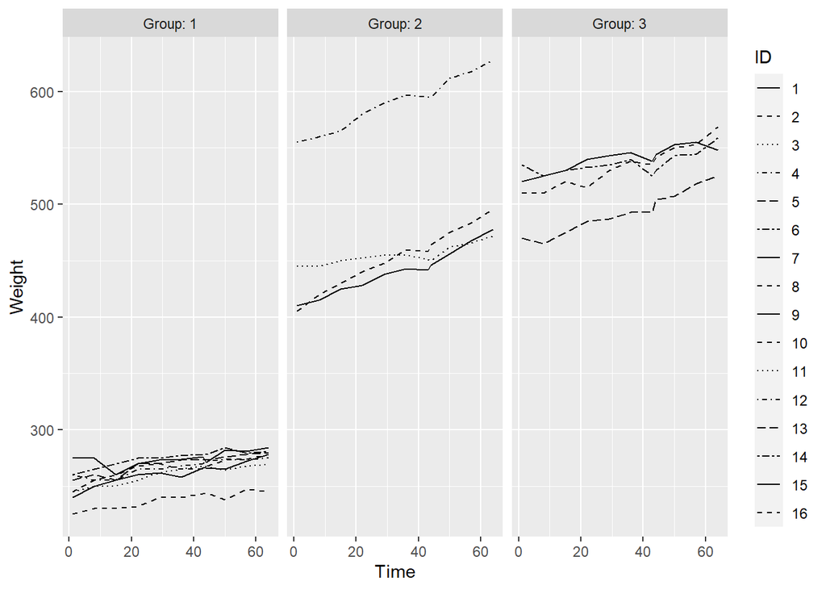

```r
# ANALYSING RATS DATA

# access the package ggplot2
library(ggplot2)

# draw the plot
ggplot(RATSL, aes(x = Time, y = Weight, linetype = ID)) +
  geom_line() +
  scale_linetype_manual(values = rep(1:8, times=2)) +
  facet_grid(. ~ Group, labeller = label_both) +
  scale_y_continuous(limits = c(min(RATSL$Weight), max(RATSL$Weight)))
```

```r
# standardise the variable bprs
RATSL <- RATSL %>%
  group_by(Time) %>%
  mutate(stdWeight = (Weight - mean(Weight))/sd(Weight)) %>%
  ungroup()

# check structure and summary anew
str(RATSL); summary(RATSL)
```

```
## tibble [176 × 6] (S3: tbl_df/tbl/data.frame)
##  $ ID       : Factor w/ 16 levels "1","2","3","4",..: 1 2 3 4 5 6 7 8 9 10 ...
##  $ Group    : Factor w/ 3 levels "1","2","3": 1 1 1 1 1 1 1 1 2 2 ...
##  $ WD       : chr [1:176] "WD1" "WD1" "WD1" "WD1" ...
##  $ Weight   : int [1:176] 240 225 245 260 255 260 275 245 410 405 ...
##  $ Time     : int [1:176] 1 1 1 1 1 1 1 1 1 1 ...
##  $ stdWeight: num [1:176] -1.001 -1.12 -0.961 -0.842 -0.882 ...
```

```
##        ID      Group       WD                Weight           Time
##  1      : 11   1:88   Length:176         Min.   :225.0   Min.   : 1.00
##  2      : 11   2:44   Class :character   1st Qu.:267.0   1st Qu.:15.00
##  3      : 11   3:44   Mode  :character   Median :344.5   Median :36.00
##  4      : 11                             Mean   :384.5   Mean   :33.55
##  5      : 11                             3rd Qu.:511.2   3rd Qu.:50.00
##  6      : 11                             Max.   :628.0   Max.   :64.00
##  (Other):110
##    stdWeight
##  Min.   :-1.1618
##  1st Qu.:-0.9084
##  Median :-0.2062
##  Mean   : 0.0000
##  3rd Qu.: 0.9235
##  Max.   : 1.6330
##
```

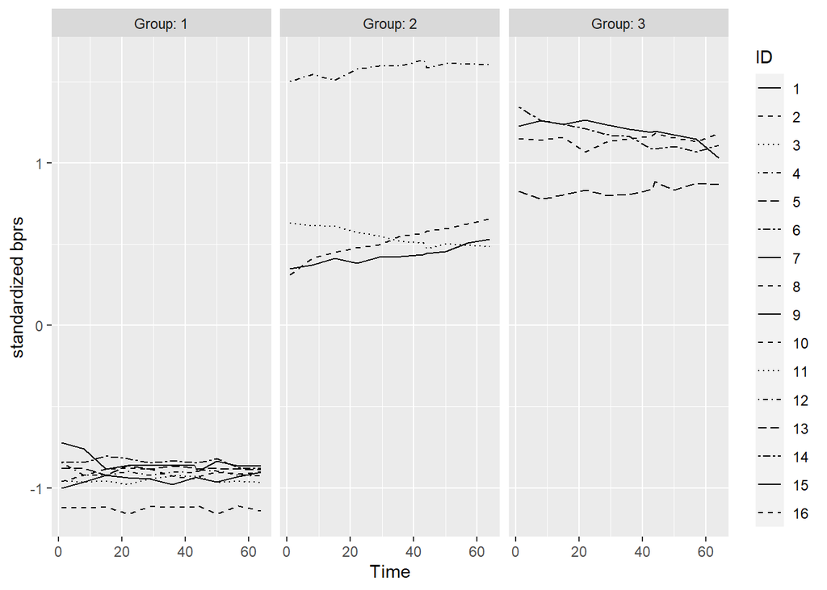

```r
# plot again with the standardized bprs
library(ggplot2)
ggplot(RATSL, aes(x = Time, y = stdWeight, linetype = ID)) +
  geom_line() +
  scale_linetype_manual(values = rep(1:8, times=2)) +
  facet_grid(. ~ Group, labeller = label_both) +
  scale_y_continuous(name = "standardized bprs")
```

Standardization decreases considerably the variability of weight as expected. In the plots, tracking can be detected and the phenomenon is somewhat clearer in the standardized plots. It is also notable that the variance of weight seems to decrease somewhat along the follow-up in all treatment groups even though it is less evident in group 1. There seems to be weight gain during time in all groups and especially in groups 2 and 3. In group 2, one rat seems to be in a league of its own.

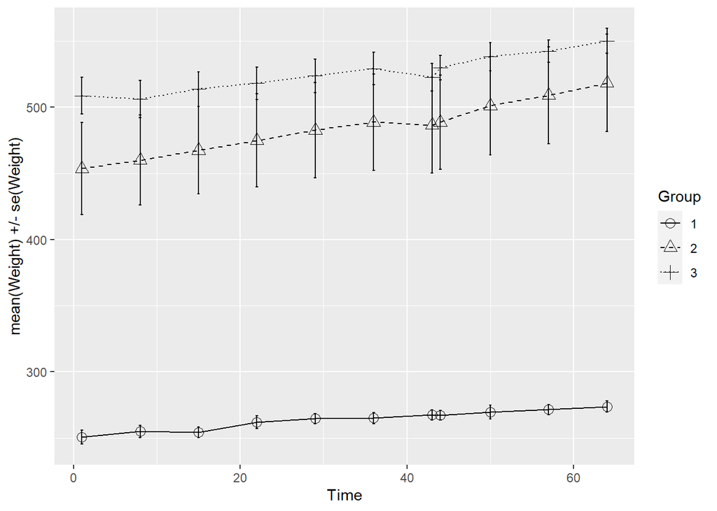

```r
# number of subjects (per group):
n <- 8   # note: group 1 has 8 rats, and groups 2 and 3 4 rats

library(tidyr)
# summary data with mean and standard error of weight by group and time
RATSS <- RATSL %>%
  group_by(Group, Time) %>%
  summarise(mean = mean(Weight), se = sd(Weight)/sqrt(n)) %>%
  ungroup()

# correction to se in groups 2 and 3
group <- RATSS$Group %>% as.numeric
RATSS$se <- ifelse(group > 1, sqrt(2)*RATSS$se, RATSS$se)

# plot the mean profiles
ggplot(RATSS, aes(x = Time, y = mean, linetype = Group, shape = Group)) +
  geom_line() +
  scale_linetype_manual(values = c(1,2,3)) +
  geom_point(size=3) +
  scale_shape_manual(values = c(1,2,3)) +
  geom_errorbar(aes(ymin=mean-se, ymax=mean+se, linetype="1"), width=0.3) +
  scale_y_continuous(name = "mean(Weight) +/- se(Weight)")
```

In the plot, mean (SE) values of weight are shown at each timepoint by treatment group. The variances are larger in groups 2 and 3 compared with group 1. Variance may decrease a little in group 3 over time but in other groups there is not much change. The seems to be weight gain in all groups but the slopes look bigger in groups 2 and 3.

```r
# create a summary data by treatment and subject with mean as the summary variable (ignoring baseline week 0)
RATSL10S <- RATSL %>%
  filter(Time > 1) %>%
  group_by(Group, ID) %>%
  summarise(mean=mean(Weight)) %>%
  ungroup()

# check structure and summary of the new object
str(RATSL10S); summary(RATSL10S)
```

```
## tibble [16 × 3] (S3: tbl_df/tbl/data.frame)
##  $ Group: Factor w/ 3 levels "1","2","3": 1 1 1 1 1 1 1 1 2 2 ...
##  $ ID   : Factor w/ 16 levels "1","2","3","4",..: 1 2 3 4 5 6 7 8 9 10 ...
##  $ mean : num [1:16] 263 239 262 267 271 ...
```

```
##  Group       ID          mean
##  1:8   1      : 1   Min.   :238.9
##  2:4   2      : 1   1st Qu.:267.4
##  3:4   3      : 1   Median :360.1
##        4      : 1   Mean   :386.3
##        5      : 1   3rd Qu.:505.4
##        6      : 1   Max.   :594.0
##        (Other):10
```

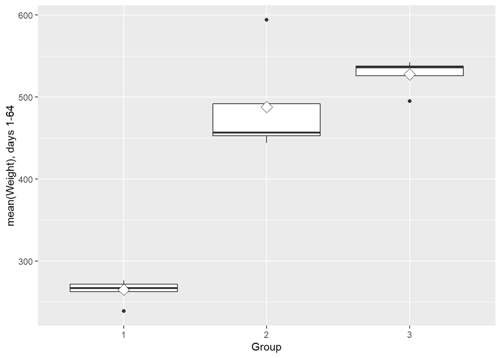

```r
# draw a boxplot of the mean versus treatment
ggplot(RATSL10S, aes(x = Group, y = mean)) +
  geom_boxplot() +
  stat_summary(fun = "mean", geom = "point", shape=23, size=4, fill = "white") +
  scale_y_continuous(name = "mean(Weight), days 1-64")
```

```r
# create a new data by filtering the outlier and adjust the ggplot code the draw the plot again with the new data
RATSL10S1 <- RATSL10S %>% filter(mean < 580)

# check structure and summary of the object
str(RATSL10S1); summary(RATSL10S1)
```

```
## tibble [15 × 3] (S3: tbl_df/tbl/data.frame)
##  $ Group: Factor w/ 3 levels "1","2","3": 1 1 1 1 1 1 1 1 2 2 ...
##  $ ID   : Factor w/ 16 levels "1","2","3","4",..: 1 2 3 4 5 6 7 8 9 10 ...
##  $ mean : num [1:15] 263 239 262 267 271 ...
```

```
##  Group       ID         mean
##  1:8   1      :1   Min.   :238.9
##  2:3   2      :1   1st Qu.:267.4
##  3:4   3      :1   Median :276.2
##        4      :1   Mean   :372.5
##        5      :1   3rd Qu.:476.4
##        6      :1   Max.   :542.2
##        (Other):9
```

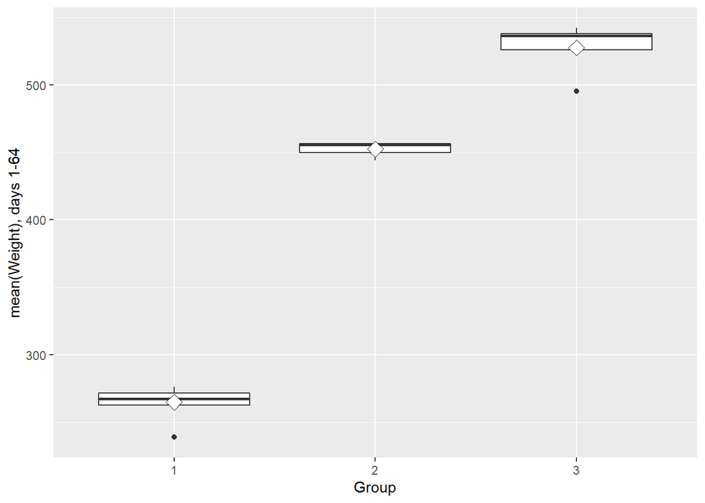

```r
# draw a boxplot of the mean versus treatment again
ggplot(RATSL10S1, aes(x = Group, y = mean)) +
  geom_boxplot() +
  stat_summary(fun = "mean", geom = "point", shape=23, size=4, fill = "white") +
  scale_y_continuous(name = "mean(Weight), days 1-64")
```

When comparing the overall means it can be seen that there is an outlier in group 2 (mean weight > 590). Filtering the outlier changes the boxplot of group 2. There is a remarkable difference between groups but it is mostly explained by the difference at baseline.

```r
# t-test can be used only for 2 groups, so fit a basic linear model instead
fit1 <- lm(mean ~ Group, data = RATSL10S1)
summary(fit1)
```

```
##
## Call:
## lm(formula = mean ~ Group, data = RATSL10S1)
##
## Residuals:
##     Min      1Q  Median      3Q     Max
## -32.300  -2.575   3.400   8.800  14.700
##
## Coefficients:
##             Estimate Std. Error t value Pr(>|t|)
## (Intercept)  265.025      5.086   52.11 1.64e-15 ***
## Group2       187.375      9.738   19.24 2.19e-10 ***
## Group3       262.475      8.809   29.80 1.28e-12 ***
## ---
## Signif. codes:  0 '***' 0.001 '**' 0.01 '*' 0.05 '.' 0.1 ' ' 1
##
## Residual standard error: 14.38 on 12 degrees of freedom
## Multiple R-squared:  0.9882, Adjusted R-squared:  0.9862
## F-statistic: 501.8 on 2 and 12 DF,  p-value: 2.721e-12
```

```r
# compute the analysis of variance table for the fitted model with anova()
anova(fit1)
```

```
## Analysis of Variance Table
##
## Response: mean
##           Df Sum Sq Mean Sq F value    Pr(>F)
## Group      2 207659  103830  501.81 2.721e-12 ***
## Residuals 12   2483     207
## ---
## Signif. codes:  0 '***' 0.001 '**' 0.01 '*' 0.05 '.' 0.1 ' ' 1
```

```r
# read the RATS data in order to get baseline values
RATS <- read.table("https://raw.githubusercontent.com/KimmoVehkalahti/MABS/master/Examples/data/rats.txt", header = TRUE, sep = '\t')

# add the baseline from the original data as a new variable to the summary data
RATSL10S2 <- RATSL10S %>%
  mutate(baseline = RATS$WD1) %>%  # note: the number of observations needs to be the same, hence filtering anew
  filter(mean < 590)

# fit the linear model with the mean as the response
fit2 <- lm(mean ~ baseline + Group, data = RATSL10S2)
summary(fit2)
```

```
##
## Call:
## lm(formula = mean ~ baseline + Group, data = RATSL10S2)
##
## Residuals:
##      Min       1Q   Median       3Q      Max
## -11.2818  -5.4247  -0.0667   5.7389  13.7887
##
## Coefficients:
##             Estimate Std. Error t value Pr(>|t|)
## (Intercept) 119.8515    31.5069   3.804 0.002923 **
## baseline      0.5792     0.1251   4.630 0.000728 ***
## Group2       89.2652    22.0021   4.057 0.001892 **
## Group3      112.9571    32.7344   3.451 0.005421 **
## ---
## Signif. codes:  0 '***' 0.001 '**' 0.01 '*' 0.05 '.' 0.1 ' ' 1
##
## Residual standard error: 8.749 on 11 degrees of freedom
## Multiple R-squared:  0.996,  Adjusted R-squared:  0.9949
## F-statistic: 911.4 on 3 and 11 DF,  p-value: 1.842e-13
```

```r
# compute the analysis of variance table for the fitted model with anova()
anova(fit2)
```

```
## Analysis of Variance Table
##
## Response: mean
##           Df Sum Sq Mean Sq   F value    Pr(>F)
## baseline   1 207817  207817 2714.9357 1.601e-14 ***
## Group      2   1483     742    9.6878  0.003748 **
## Residuals 11    842      77
## ---
## Signif. codes:  0 '***' 0.001 '**' 0.01 '*' 0.05 '.' 0.1 ' ' 1
```

As expected, in the base model, the mean overall weight differs significantly between groups and the results are in concordance with the previous plot. The model explains 99% of the variation in mean overall weight. The mean overall weight in group 2 is 187 g higher and in group 262 g higher compared with group 1. But the result does not tell anything about the differences in weight gain between the groups during the experiment.

Baseline weight is a statistically significant addition to the model: it explains vastly more of the variation than treatment. Yet, there seems to be statistically significant effect by group: the mean overall weight in group 2 is still 89 g higher and in group 113 g higher compared with group 1.

Using the overall mean can be justified if we are interested in the treatment effect along the whole time and not just the end situation. If we are interested only in the final status, especially if we expect that status to be more or less permanent, the more accurate comparison might be to compare the weight status at the end.

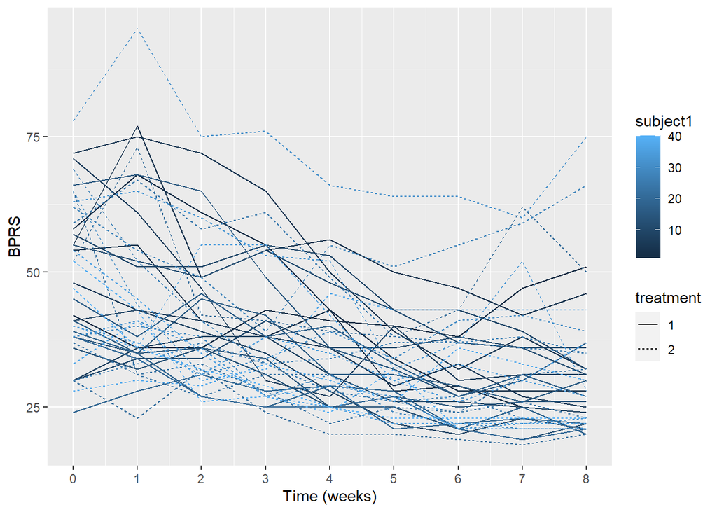

```r
# # ANALYSING BPRS DATA

# Plot the BPRS data (note: each subject needs ty be identified by subject number)
treatment <- BPRSL$treatment %>% as.numeric
BPRSL$subject1 <- ifelse(treatment == 2, 20+as.numeric(BPRSL$subject), as.numeric(BPRSL$subject))
ggplot(BPRSL, aes(x = week, y = bprs, group = subject1, color = subject1)) +
  geom_line(aes(linetype = treatment)) + scale_x_continuous(name = "Time (weeks)", breaks = seq(0, 8, 1)) +
  scale_y_continuous(name = "BPRS")
```

```r
# Check the structure of the data
str(BPRSL)
```

```
## 'data.frame':    360 obs. of  6 variables:
##  $ treatment: Factor w/ 2 levels "1","2": 1 1 1 1 1 1 1 1 1 1 ...
##  $ subject  : Factor w/ 20 levels "1","2","3","4",..: 1 2 3 4 5 6 7 8 9 10 ...
##  $ weeks    : chr  "week0" "week0" "week0" "week0" ...
##  $ bprs     : int  42 58 54 55 72 48 71 30 41 57 ...
##  $ week     : int  0 0 0 0 0 0 0 0 0 0 ...
##  $ subject1 : num  1 2 3 4 5 6 7 8 9 10 ...
```

In the plot, there does not seem to be much difference between groups. Tracking seems prevalent and the variation of BPRS seems to decrease by time.

```r
# create a regression model BPRS_reg
BPRS_reg <- lm(bprs ~ week + treatment, data = BPRSL)

# print out a summary of the model
summary(BPRS_reg)
```

```
##
## Call:
## lm(formula = bprs ~ week + treatment, data = BPRSL)
##
## Residuals:
##     Min      1Q  Median      3Q     Max
## -22.454  -8.965  -3.196   7.002  50.244
##
## Coefficients:
##             Estimate Std. Error t value Pr(>|t|)
## (Intercept)  46.4539     1.3670  33.982   <2e-16 ***
## week         -2.2704     0.2524  -8.995   <2e-16 ***
## treatment2    0.5722     1.3034   0.439    0.661
## ---
## Signif. codes:  0 '***' 0.001 '**' 0.01 '*' 0.05 '.' 0.1 ' ' 1
##
## Residual standard error: 12.37 on 357 degrees of freedom
## Multiple R-squared:  0.1851, Adjusted R-squared:  0.1806
## F-statistic: 40.55 on 2 and 357 DF,  p-value: < 2.2e-16
```

```r
# access library lme4
library(lme4)

# Create a random intercept model
BPRS_ref <- lmer(bprs ~ week + treatment + (1 | subject1), data = BPRSL, REML = FALSE)

# print the model summary
summary(BPRS_ref)
```

```
## Linear mixed model fit by maximum likelihood  ['lmerMod']
## Formula: bprs ~ week + treatment + (1 | subject1)
##    Data: BPRSL
##
##      AIC      BIC   logLik deviance df.resid
##   2582.9   2602.3  -1286.5   2572.9      355
##
## Scaled residuals:
##      Min       1Q   Median       3Q      Max
## -2.27506 -0.59909 -0.06104  0.44226  3.15835
##
## Random effects:
##  Groups   Name        Variance Std.Dev.
##  subject1 (Intercept) 97.39    9.869
##  Residual             54.23    7.364
## Number of obs: 360, groups:  subject1, 40
##
## Fixed effects:
##             Estimate Std. Error t value
## (Intercept)  46.4539     2.3521  19.750
## week         -2.2704     0.1503 -15.104
## treatment2    0.5722     3.2159   0.178
##
## Correlation of Fixed Effects:
##            (Intr) week
## week       -0.256
## treatment2 -0.684  0.000
```

In the fixed effects model, the observations are modeled as if they are independent from each other. Time (week) is a significant explanatory variable but treatment group is not. The model explains only 19% of variation in BPRS points. The fixed effects estimate for week (-2.3) implies 18 points decrease in 8 weeks which can be considered clinically significant. So time seems to heal but not the treatment.

In the random effects model, the variation between subjects is being taken into account. The fixed effects estimates remain the same but a part of the variance in BPRS points seems to be explained by random effects between subjects.

```r
# create a random intercept and random slope model
BPRS_ref1 <- lmer(bprs ~ week + treatment + (week | subject1), data = BPRSL, REML = FALSE)

# print a summary of the model
summary(BPRS_ref1)
```

```
## Linear mixed model fit by maximum likelihood  ['lmerMod']
## Formula: bprs ~ week + treatment + (week | subject1)
##    Data: BPRSL
##
##      AIC      BIC   logLik deviance df.resid
##   2523.2   2550.4  -1254.6   2509.2      353
##
## Scaled residuals:
##     Min      1Q  Median      3Q     Max
## -2.4655 -0.5150 -0.0920  0.4347  3.7353
##
## Random effects:
##  Groups   Name        Variance Std.Dev. Corr
##  subject1 (Intercept) 167.827  12.955
##           week          2.331   1.527   -0.67
##  Residual              36.747   6.062
## Number of obs: 360, groups:  subject1, 40
##
## Fixed effects:
##             Estimate Std. Error t value
## (Intercept)  45.9830     2.6470  17.372
## week         -2.2704     0.2713  -8.370
## treatment2    1.5139     3.1392   0.482
##
## Correlation of Fixed Effects:
##            (Intr) week
## week       -0.545
## treatment2 -0.593  0.000
```

```r
# perform an ANOVA test on the two models
anova(BPRS_ref1, BPRS_ref)
```

```
## Data: BPRSL
## Models:
## BPRS_ref: bprs ~ week + treatment + (1 | subject1)
## BPRS_ref1: bprs ~ week + treatment + (week | subject1)
##           npar    AIC    BIC  logLik deviance  Chisq Df Pr(>Chisq)
## BPRS_ref     5 2582.9 2602.3 -1286.5   2572.9
## BPRS_ref1    7 2523.2 2550.4 -1254.6   2509.2 63.663  2  1.499e-14 ***
## ---
## Signif. codes:  0 '***' 0.001 '**' 0.01 '*' 0.05 '.' 0.1 ' ' 1
```

Taking into account the dependence of BPRS points across time by each subject by adding week in the random effects model, there is still no treatment effect. On the other hand, there seems to be time dependence: when comparing models with and without week AIC decreases and logLik increases, the difference being statistically significant. There are minor changes in the fixed effects estimates.

These models show that large part of the variation between BPRS values can be explained by interindividual and intraindividual random variation. The impression that in this case time heals, not the treatment, becomes stronger.

```r
# create a random intercept and random slope model with the interaction
BPRS_ref2 <- lmer(bprs ~ week + treatment + week * treatment + (week | subject1), data = BPRSL, REML = FALSE)

# print a summary of the model
summary(BPRS_ref2)
```

```
## Linear mixed model fit by maximum likelihood  ['lmerMod']
## Formula: bprs ~ week + treatment + week * treatment + (week | subject1)
##    Data: BPRSL
##
##      AIC      BIC   logLik deviance df.resid
##   2523.5   2554.5  -1253.7   2507.5      352
##
## Scaled residuals:
##     Min      1Q  Median      3Q     Max
## -2.4747 -0.5256 -0.0866  0.4435  3.7884
##
## Random effects:
##  Groups   Name        Variance Std.Dev. Corr
##  subject1 (Intercept) 164.204  12.814
##           week          2.203   1.484   -0.66
##  Residual              36.748   6.062
## Number of obs: 360, groups:  subject1, 40
##
## Fixed effects:
##                 Estimate Std. Error t value
## (Intercept)      47.8856     2.9840  16.047
## week             -2.6283     0.3752  -7.006
## treatment2       -2.2911     4.2200  -0.543
## week:treatment2   0.7158     0.5306   1.349
##
## Correlation of Fixed Effects:
##             (Intr) week   trtmn2
## week        -0.668
## treatment2  -0.707  0.473
## wek:trtmnt2  0.473 -0.707 -0.668
```

```r
# perform an ANOVA test on the two models
anova(BPRS_ref2, BPRS_ref1)
```

```
## Data: BPRSL
## Models:
## BPRS_ref1: bprs ~ week + treatment + (week | subject1)
## BPRS_ref2: bprs ~ week + treatment + week * treatment + (week | subject1)
##           npar    AIC    BIC  logLik deviance Chisq Df Pr(>Chisq)
## BPRS_ref1    7 2523.2 2550.4 -1254.6   2509.2
## BPRS_ref2    8 2523.5 2554.6 -1253.7   2507.5  1.78  1     0.1821
```

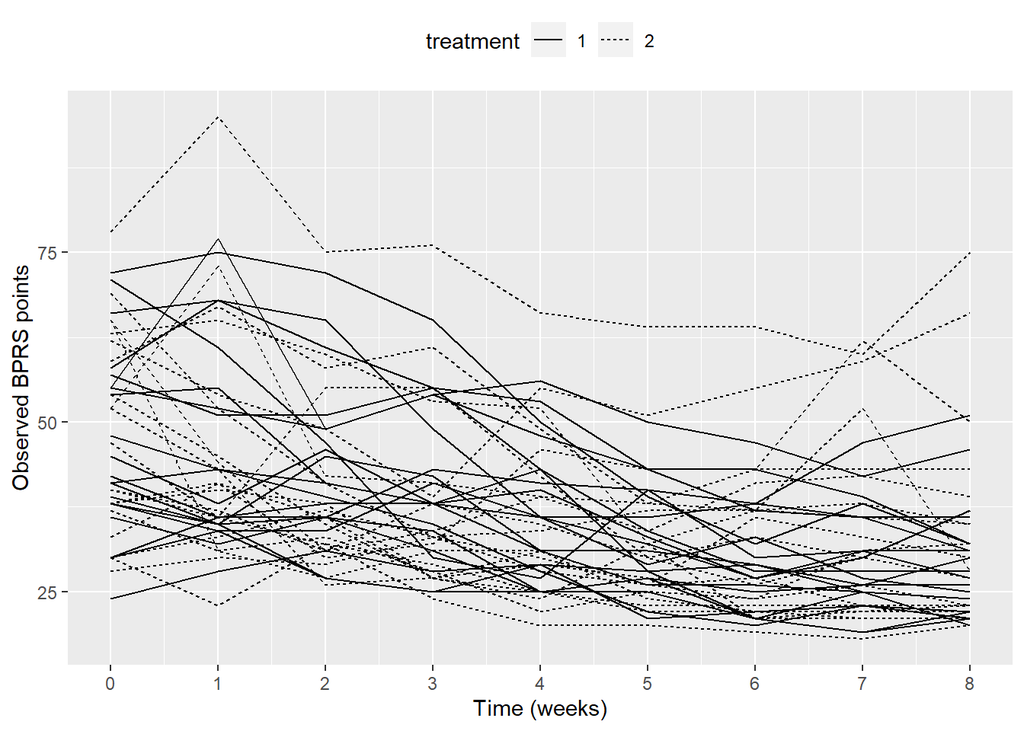

```r
# draw the plot of RATSL with the observed Weight values
ggplot(BPRSL, aes(x = week, y = bprs, group = subject1)) +
  geom_line(aes(linetype = treatment)) +
  scale_x_continuous(name = "Time (weeks)", breaks = seq(0, 8, 1)) +
  scale_y_continuous(name = "Observed BPRS points") +
  theme(legend.position = "top")
```

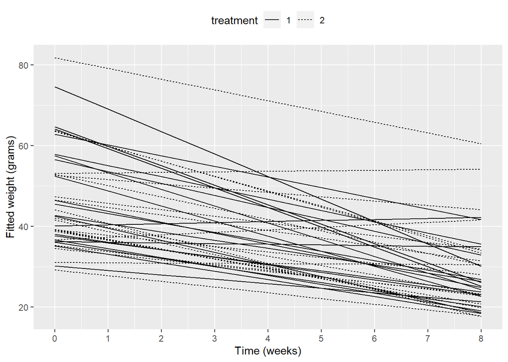

```r
# Create a vector of the fitted values
Fitted <- fitted(BPRS_ref2)
# Create a new column fitted to RATSL
BPRSL <- BPRSL %>% mutate(Fitted = Fitted)

# draw the plot of RATSL with the Fitted values of weight
ggplot(BPRSL, aes(x = week, y = Fitted, group = subject1)) +
  geom_line(aes(linetype = treatment)) +
  scale_x_continuous(name = "Time (weeks)", breaks = seq(0, 8, 1)) +
  scale_y_continuous(name = "Fitted weight (grams)") +
  theme(legend.position = "top")
```

Adding interaction term for week and treatment into the random effects model does not improve the model, AIC and logLik do not practically change at all. The model is able to fit the observations reasonably well if one is willing to believe that the relationship between BPRS and time is linear; yet, a second-degree polynomial model might be better.